# Assignment6

By *Changyu Gao*, PB15121717

## 6.21

Create data matrices

```r
n <- 20
p <- 4
S1 <- matrix(c(.459, .254, -.026, -.244,
               .254, 27.465, -.589, -.267,
               -.026, -.589, .030, .102,
               -.244, -.267, .102, 6.854), nrow = 4)
S2 <- matrix(c(.944, -.089, .002, -.719,
               -.089, 16.432, -.400, 19.044,
               .002, -.4, .024, -.094,
               -.719, 19.044, -.094, 61.854), nrow = 4)
Spool <- matrix(c(.701, .083, -.012, -.481,
                  .083, 21.949, -.494, 9.388,
                  -.012, -.494, .027, .004,
                  -.481, 9.388, .004, 34.354), nrow = 4)
x1 <- c(2.287, 12.6, .347, 14.83)
x2 <- c(2.404, 7.155, .524, 12.840)
```

1. We notice that S1 and S2 differ a lot and n1, n2 are not large. Therefore, the pooling procedure may not work very well.

Test for equality of mean vectors

```r
d <- x1 - x2 # difference of mean vectors
T2 <- d %*% solve(2/n * Spool, d)
T2
```

```
##          [,1]
## [1,] 15.83653
```

```r
alpha <- .05
fscale <- function(p, n, a) {
  p*(n-1)/(n-p)/n * qf(1-a, p, n-p)
}
threshold <- (2*n-1) * fscale(p, 2*n-1, alpha) # critical value
threshold
```

```
## [1] 11.47151
```

```r
comb <- solve(Spool, d)
comb
```

```
## [1] -0.24210856  0.16013330 -3.73497395  0.01121134
```

```r
comb0 <- comb * sqrt(diag(Spool))
comb0
```

```
## [1] -0.2027072  0.7502207 -0.6137188  0.0657122
```

2. Here the $T^2$ statistic is greater than the critical value. Hence, we reject $H_0: \mu_1 - \mu_2 = 0$ at the significant level $\alpha=.05$.
3. And we find the most responsible linear combination vector $\bar a=(-.24, .16, -3.7, .01)$ by computing $S_{pooled}^{-1}(\bar x_1 - \bar x_2)$.
4. We compute the standardized vector of $\bar a$ and get $\bar a=(-.20, .75, -.61, .07)$. The second component has the largest magnitude, implying the long-term interest rate might be useful to classify a bond.

Using approximations when covariance matrices are unequal

```r
I1 <- 1/n * solve((S1 + S2) / n , S1)
I2 <- 1/n * solve((S1 + S2) / n , S2)
tr <- function(A) {
  if (ncol(A) == nrow(A)) sum(diag(A))
} # trace function
v <- (p + p^2) * n/ (tr(I1 %*% I1) + tr(I1) ^ 2 +
                  tr(I2 %*% I2) + tr(I2) ^ 2)
threshold <- v*p / (v-p+1) * qf(1-alpha, p, v-p+1)
threshold
```

```
## [1] 11.51259
```

5. We compute the critical value and find it very close to that in b) (difference < .05). Since $T^2$ statistic is greater than the critical value, we reject $H_0: \mu_1 - \mu_2 = 0$ at the significant level $\alpha=.05$. Our conclusion doesn’t change.

## 8.10

Import data

```r
X <- read.table("T8-4.DAT")
head(X)
```

```
##           V1         V2         V3         V4         V5
## 1  0.0130338 -0.0078431 -0.0031889 -0.0447693  0.0052151
## 2  0.0084862  0.0166886 -0.0062100  0.0119560  0.0134890
## 3 -0.0179153 -0.0086393  0.0100360  0.0000000 -0.0061428
## 4  0.0215589 -0.0034858  0.0174353 -0.0285917 -0.0069534
## 5  0.0108225  0.0037167 -0.0101345  0.0291900  0.0409751
## 6  0.0101713 -0.0121978 -0.0083768  0.0137083  0.0029895
```

```r
S <- cov(X)
S
```

```
##              V1           V2           V3           V4           V5
## V1 4.332695e-04 0.0002756679 1.590265e-04 6.411929e-05 8.896616e-05
## V2 2.756679e-04 0.0004387172 1.799737e-04 1.814512e-04 1.232623e-04
## V3 1.590265e-04 0.0001799737 2.239722e-04 7.341348e-05 6.054612e-05
## V4 6.411929e-05 0.0001814512 7.341348e-05 7.224964e-04 5.082772e-04
## V5 8.896616e-05 0.0001232623 6.054612e-05 5.082772e-04 7.656742e-04
```

```r
pca <- prcomp(X)
n1 <- nrow(X)
summary(pca)
```

```
## Importance of components:
##                            PC1     PC2     PC3     PC4     PC5
## Standard deviation     0.03698 0.02648 0.01593 0.01194 0.01090
## Proportion of Variance 0.52926 0.27133 0.09822 0.05518 0.04601
## Cumulative Proportion  0.52926 0.80059 0.89881 0.95399 1.00000
```

```r
eigval <- pca$sdev ^ 2 # eigenvalues
eigval
```

```
## [1] 0.0013676780 0.0007011596 0.0002538024 0.0001426026 0.0001188868
```

```r
pca$rotation # show eigenvectors, i.e. principal components
```

```
##           PC1        PC2         PC3        PC4         PC5
## V1 -0.2228228  0.6252260 -0.32611218  0.6627590 -0.11765952
## V2 -0.3072900  0.5703900  0.24959014 -0.4140935  0.58860803
## V3 -0.1548103  0.3445049  0.03763929 -0.4970499 -0.78030428
## V4 -0.6389680 -0.2479475  0.64249741  0.3088689 -0.14845546
## V5 -0.6509044 -0.3218478 -0.64586064 -0.2163758  0.09371777
```

1. Covariance matrix and principal components are shown above.
2. From the summary we see that the first three components account for 89.9% of total variance

Compute Bonferroni simultaneous 90% confidence intervals

```r
alpha1 <- 0.1
fac <- qnorm(1-alpha1/(2*3)) * sqrt(2/n1)
eigval[1:3] / (1+fac) # lower end
```

```
## [1] 0.0010548710 0.0005407946 0.0001957543
```

```r
eigval[1:3] / (1-fac) # upper end
```

```
## [1] 0.0019442044 0.0009967240 0.0003607895
```

3. Corresponding confidence intervals are shown above.

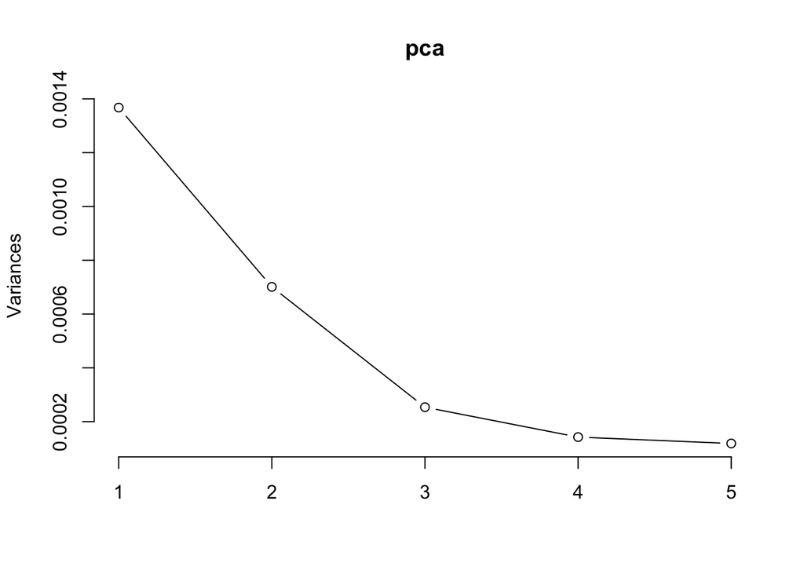

```r
screeplot(pca, type = "lines")
```

4. We plot the screeplot and decide that the data can be summarized with the first three principal components which altogether contribute to ~90% of the total variance.